# R-Data Processing

Jong-June Jeon

May, 2018

## R Data processing by index

## Indexing 및 Filtering 을 이용한 데이터 정리

– Survey 데이터를 부르고 열 이름을 확인하자.

[output not shown]

## Indexing 및 Filtering 을 이용한 데이터 정리

- `surveys` 데이터프레임에서 "plot_id", "species_id", "weight" 열을 골라보자
- `names(surveys)` 는 데이터프레임의 열 이름을 출력하는 함수다.
- `match` 함수의 용법은 R-graphical tool, R Basic(Review) 단원을 참고하여라.

```r
match(c("plot_id", "species_id", "weight"),  names(surveys))
surveys[, match(c("plot_id", "species_id", "weight"),  names(surveys)) ]
```

## Indexing 및 Filtering 을 이용한 데이터 정리

- 데이터프레임의 column 을 인덱싱 하는 부분에 추출하고자 하는 열의 이름에 해당하는 문자열 벡터를 입력해도 같은 결과를 얻는다.

```r
surveys[,c("plot_id", "species_id", "weight") ]
```

- 혹은 데이터프레임이 List라는 성질을 이용하여 List에서 Slicing 방법을 이용할 수 있다.

```r
surveys[c("plot_id", "species_id", "weight")]
```

## Indexing 및 Filtering 을 이용한 데이터 정리

- `year` 값이 1995인 데이터 행만 추출하고자 한다.
- 데이터프레임에 행렬에서 행의 Slicing 방법을 적용한다.

```r
surveys$year == 1995
surveys[surveys$year == 1995, ]
head(surveys[surveys$year == 1995, ])
```

## Indexing 및 Filtering 을 이용한 데이터 정리

- `weight`값이 5미만인 데이터에 대해서 "species_id", "sex", "weight" 열을 보고자 한다.
- 데이터프레임에 행렬에서 행과 열의 Slicing 방법을 적용한다.
- 다음 두개의 코드를 비교하여라.

```r
surveys[surveys$weight<5, c("species_id", "sex", "weight")]
```

```r
surveys[which(surveys$weight<5), c("species_id", "sex", "weight")]
```

- 결과에서 어떤 차이가 있는가? 이런 차이는 왜 발행하는가?

## Indexing 및 Filtering 을 이용한 데이터 정리

- `surveys` 데이터에 `weight_kg` 열을 추가하여 `surveys_ex` 데이터프레임을 생성하고자 한다. `weight_kg`열은 `weight`열을 1000으로 나눈 값을 가진다. 단, `surveys_ex` 데이터는 `weight_kg`값이 `NA`인 것은 제외한다.
- 데이터프레임에 열을 추가하는 방법은 `cbind()`를 사용하는 것도 가능하지만, `list`에서 데이터를 추가하는 방법을 사용하는 것도 가능하다.
- `is.na()`를 사용하여 데이터프레임을 slicing 한다.

```r
surveys_ex <- surveys
surveys_ex$weight_kg <- surveys_ex$weight/1000
surveys_ex <- surveys_ex[!is.na(surveys_ex$weight_kg),]
```

## Indexing 및 Filtering 을 이용한 통계량의 계산

- `surveys` 데이터에서 `sex`별로 `weight`값의 평균을 계산하고자 한다. 단, `NA`값은 제외하고 계산하고자 한다.
- `sex` 의 유일한 값은 어떻게 되나?

```r
u = unique(surveys$sex)
length(u)
class(surveys$sex)
levels(surveys$sex)
```

- `surveys$sex` 가 `factor`이므로 `levels()` 함수를 사용할 수 있다. 만약 그 변수가 `character`면 `unique`함수를 사용해야 한다.

## Indexing 및 Filtering 을 이용한 통계량의 계산

- `sex`별로 `weight`값의 평균을 계산

```r
mean( surveys$weight[surveys$sex == u[1]], na.rm = T )
mean( surveys$weight[surveys$sex == u[2]], na.rm = T )
mean( surveys$weight[surveys$sex == u[3]], na.rm = T )
```

## Indexing 및 Filtering 을 이용한 통계량의 계산

- `by` 함수의 이용

```r
by( data = surveys$weight, INDICES =  surveys$sex,
    FUN  = mean, na.rm = TRUE)
```

- `aggregate` 함수의 이용

```r
aggregate(formula = weight ~ sex, data = surveys,
          FUN = mean, na.rm = TRUE)
```

## Indexing 및 Filtering 을 이용한 통계량의 계산

- `sex`와 `species_id` 별로 `weight`값의 평균을 계산
- `by`문을 사용할 수 있지만, 다음과 같이 `aggregate` 함수를 이용해 간단히 표현할 수 있다.

```r
aggregate(formula = weight ~ sex + species_id,
          data = surveys, FUN = mean, na.rm = TRUE)
```

## Indexing 및 Filtering 을 이용한 통계량의 계산

- `surveys` 데이터의 성별의 빈도, (성별, `plot_id`)빈도를 계산하여라.

```r
table(surveys$sex)
table(surveys$sex, surveys$plot_id)
```

## Indexing 및 Filtering 을 이용한 통계량의 계산

- `plot_id` 값의 오름차순으로 `surveys` 데이터를 정렬하여라.

```r
surveys[order(surveys$plot_id),]
```

- 먼저 `month`값을 내림차순으로 정렬하고 그 순서를 유지시키면서 `plot_id` 값의 오름차순으로 `surveys` 데이터를 정렬하여라.

```r
tmp <- surveys
tmp <- tmp[order(tmp$plot_id),]
tmp <- tmp[order(tmp$month, decreasing = TRUE),]
head(tmp)
```

## R dplyr

## R dplyr

- Hadley Wickham가 작성한 데이터 처리에 특화된 R 패키지
- Hadley Wickham 은 뉴질랜드 통계학자로 RStudio 수석 과학자, Rice University의 겸임교수로 재직중임.
- dplyr 의 중요한 함수로는 `select`, `filter`, `mutate`, `group_by`, `summarize`와 연산자인 파이프함수 `%>%` 가 있다.
- `dplyr`는 디플라이어 (데이터 플라이어: 데이터를 다루는 작은 집게)라고 흔히 부른다.
- 특히 파이프라인 연산자는 코드의 가독성을 높여주는데 큰 기여를 한다.

```r
if (!require(dplyr)) { install.packages("dplyr") ; library(dplyr) }
```

## R dplyr

- `surveys` 데이터프레임에서 "plot_id", "species_id", "weight" 열을 골라보자.
- `select` 함수를 이용하여 고를 수 있다.

```r
select(.data = surveys, plot_id, species_id, weight)
```

- 파이프라인 연산자인 `%>%`의 사용방법을 확인하여라.

```r
head(select(surveys, plot_id, species_id, weight))
select(.data = surveys, plot_id, species_id, weight) %>% head()
```

## R dplyr

```r
filter(.data = surveys, year == 1995) %>% head()
```

- `year` 값이 1995이상이고 `weight`가 20보다 큰 데이터 행만 추출하고자 한다.

```r
filter(.data = surveys, year >= 1995 & weight > 20) %>% head()
filter(.data = surveys, year >= 1995 , weight > 20) %>% head()
```

## R dplyr

- `weight`값이 5미만인 데이터에 대해서 "species_id", "sex", "weight" 열을 보고자 한다. 그리고 `weight`가 NA인 것은 제외하고 싶다.

```r
surveys %>%
  filter( !is.na(weight) ) %>%
  filter(weight < 5) %>%
  select(species_id, sex, weight) %>% head()
```

## R dplyr

- `surveys` 데이터에 `weight_kg` 열을 추가하여 `surveys_ex` 데이터프레임을 생성하고자 한다. `weight_kg`열은 `weight`열을 1000으로 나눈 값을 가진다. 단, `surveys_ex` 데이터는 `weight_kg`값이 `NA`인 것은 제외한다.

```r
surveys_ex <- surveys %>% filter( !is.na(surveys$weight)) %>%
  mutate(weight_kg = weight / 1000)
```

## R dplyr 을 이용한 통계량 추출

- `surveys` 데이터에서 `sex`별로 `weight`값의 평균을 계산하고자 한다. 단, `NA`값은 제외하고 계산하고자 한다.

```r
surveys %>%
  group_by(sex) %>%
  summarize(mean_weight = mean(weight, na.rm = TRUE))
```

## R dplyr 을 이용한 통계량 추출

- `sex`와 `species_id` 별로 `weight`값의 평균을 계산

```r
surveys %>%
  filter(!is.na(weight)) %>%
  group_by(sex, species_id) %>%
  summarize(mean_weight = mean(weight, na.rm = TRUE))
```

## R dplyr 을 이용한 통계량 추출

- `sex`와 `species_id` 별로 `weight`값의 평균과 분산과 최소값과 최대값의 계산

```r
surveys %>%
  filter(!is.na(weight)) %>%
  group_by(sex, species_id) %>%
  summarize(mean_weight = mean(weight),
            var_weight = var(weight),
            min_weight = min(weight),
            max_weight = max(weight)) %>%
  print(n = 5)
```

## R dplyr 을 이용한 통계량 추출

- `surveys` 데이터의 성별의 빈도, (성별, `plot_id`)빈도를 계산하여라.

```r
surveys %>%
  group_by(sex) %>%
  tally()

surveys %>%
  group_by(plot_id, sex) %>%
  tally()
```

## R dplyr 을 이용한 통계량 추출

```r
surveys %>% arrange(month, plot_id) %>% head()
```

- 먼저 `month`값을 내림차순으로 정렬하고 그 순서를 유지시키면서 `plot_id` 값의 오름차순으로 `surveys` 데이터를 정렬하여라.

```r
surveys %>% arrange(desc(month), plot_id) %>% head()
```

## reshape2

## Long format and wide format

- wide format

```
##   Ozone Solar.R Wind Temp Month Day
## 1    41     190  7.4   67     5   1
## 2    36     118  8.0   72     5   2
## 3    12     149 12.6   74     5   3
```

- Long format

```
##   variable value
## 1    Ozone    41
## 2    Ozone    36
## 3    Ozone    12
```

## Long format and wide format

데이터 분석시 사용되는 함수에 따라 요구하는 데이터의 포맷이 다를 수 있다.

- Wide format: almost modeling function such as `lm`, `glm`, `gam`,…
- Long format: `ggplot2`

`reshape2` 라이브러리는 데이터 포맷의 변경 및 간단한 요약통계량을 산출해주는 함수를 가지고 있다.

## melt

- `melt` 함수는 wide format 데이터를 long format 데이터로 변경해준다.

```r
names(airquality) <-  tolower(names(airquality))
melt(data = airquality) %>% head(n=3)
```

```
##   variable value
## 1    ozone    41
## 2    ozone    36
## 3    ozone    12
```

## melt

- `melt` 함수에 `id.vars`을 지정해줌으로써 long format은 행을 구분해 줄 수 있는 식별자를 지정해줄 수 있다.

```r
names(airquality) <-  tolower(names(airquality))
aql <- melt(data = airquality, id.vars= c("month","day"))
head(aql, n = 3)
```

```
##   month day variable value
## 1     5   1    ozone    41
## 2     5   2    ozone    36
## 3     5   3    ozone    12
```

- 다음과 같이 `variable`과 `value`에 값의 이름을 지정해 줄 수 있다.

```
##   month day climate_variable climate_value
## 1     5   1            ozone            41
## 2     5   2            ozone            36
## 3     5   3            ozone            12
```

## dcast

- dcast는 long format 데이터를 wide format 데이터로 변경하는 함수다.

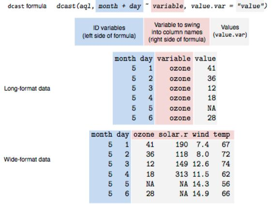

```r
knitr::include_graphics("./fig/reshape2-1.JPG")
```

## dcast

```r
if (!require(reshape2)) { install.packages("reshape2") ; library(reshape2) }

aqw <- dcast(aql, month + day ~ climate_variable,
             value.var ="climate_value")
```

- dcast 예제

```r
dcast(aql, month ~ climate_variable, fun.aggregate = mean,
      na.rm = TRUE, margins  = TRUE) %>% head(n=3)
```

```
##   month    ozone  solar.r      wind     temp    (all)
## 1     5 23.61538 181.2963 11.622581 65.54839 68.70696
## 2     6 29.44444 190.1667 10.266667 79.10000 87.38384
## 3     7 59.11538 216.4839  8.941935 83.90323 93.49748
```

```
- 여기서 `margins = TRUE` 를 생략하고 결과를 비교하여라.
- `margins`와 관련한 다른 option 을 찾아보아라.
```

## Exercise

## Skillcraft

[figure not shown]

## Skillcraft

### 게임의 개요

- RTS game: real-time strategy (RTS) games
- 멀리플레이 온라인 게임: 다수의 사용자가 참가해 승패를 가리는 온라인 게임
- 개인 플레이 (1:1), 팀플레이 (2:2~4:4)로 정해진 기준에 의해 승패가 결정
- 모든 건물의 파괴
- 게임 포기 등.
- 온라인 상에서 플레이어간에 일방적인 경기가 나오지 않도록 플레이어 매칭을 고려, 등급제 실시
- [데이터 다운로드](http://archive.ics.uci.edu/ml/datasets/skillcraft1+master+table+dataset)

## Skillcraft

### 플레이어의 등급

- Bronze, Silver, Gold, Platinum, Diamond, Master, GrandMaster, and Professional leagues
- Bronze 등급이 가장 초보적인 수준의 플레이가 받게 되는 등급, Professional leagues가 최고수준의 플레이어가 받게 되는 등급
- 게임의 등급을 통한 플레이어 매칭은 여러 게임에서 사용되고 있음. ex) league of legend

[figure not shown]

## Skillcraft

- SkillCraft1:Master Table Dataset Data Set
- 데이터 제공자: Mark Blair, Joe Thompson, Andrew Henrey, Bill Chen, Mark Blair: Department of Psychology; Simon Fraser University
- 날짜: September, 20, 2013

### 데이터 수집 방법

- StarCraft 2 replay file에서 스크린 내에서 발생하는 플레이어의 입력 정보를 Salvucci & Goldberg (2000) dispersion-threshold 알고리즘을 이용하여 1초당 약 88.5개의 시분할 작업을 수집하였음
- StarCraft 2 replay file: 하나의 게임이 저장되어 게임 내에서 일어난 전체정보를 담고 있는 파일. 이 파일로 기록된 게임의 모든 정보를 얻을 수 있음

## Skillcraft

### 데이터 정보

- AssignToHotkeys: 핫키에 할당된 건물 또는 유닛수
- UniqueHotkeys: 유니크 핫키의 사용수
- MinimapAttacks: 미니맵을 통한 공격횟수
- MinimapRightClicks: 미니맵을 이용한 우클릭 횟수 (공격 또는 이동)

## Skillcraft

### 데이터 정보

- PAC : Perception-Action-Cycles. 특정 유닛을 클릭한 후 명령을 완료하는 동작 NumberOfPACs
- GapBetweenPACs
- ActionLatency: PAC의 첫번째 동작에서 완료할 동작까지 걸리는 평균시간
- ActionsInPAC: PAC 내에서 일어나는 작업의 수
- TotalMapExplored
- WorkersMade: 하나의 타임프레임 내의 평균 일꾼수
- UniqueUnitsMade: 하나의 타임프레임 내에서 Unique한 유닛의 수 (다양성)
- ComplexUnitsMade: 다루기 어려운 유닛의 평균 수 (ghosts, infestors, and high templars )
- ComplexAbilitiesUsed

## Skillcraft

- 등급별로 Skillcraft 데이터의 탐색적 자료분석을 실시하여라.

## Wine Quality data

[figure not shown]

## Wine Quality data

### 포르투칼 와인

- vinho verde wine 산업
- 포르투갈 북부지방에 Minho province 지역에서 시작되었음
- 레드, 화이트, 로제 와인을 생산하고 있음
- 2014년 약 19000개의 작은 농장이 있음
- 포르투칼 와인 수출이 1997~2007년 사이 36% 증가하였음

### 와인의 성격

- 약간의 기포가 있어 청량감이 있으나 스파클링 와인으로는 구분하지 않음
- 도수는 11.5~14도 정도 임.
- 화이트 와인은 상큼한 과일향과 청량감이 특징임.

## Wine Quality data

### 와인의 평가

- 감각에 의한 평가 (sensory test)
- 주로 시음자에 의해서 이루어짐
- 몇몇 평가는 상업적으로 많이 사용되기도 함: ex) 로버트 파커 rating

### 물리화학적 평가 (physicochemical test)

- 와인의 화학적 성분을 실험실에서 측정한 다음, 그것들의 특징을 찾는 작업
- 물리화학적 평가와 감각에 의한 평가에 대한 관계가 있을것으로 예상하나 몇몇 연구에 제한되어 있음

## Wine Quality data

### 품질 평가가 왜 필요한가?

- 소비자의 욕구 충족
- 적절한 가격 책정
- Taste preferenc의 분석을 통한 맞춤형 wine 추천 등….

### 물리화학적 평가와 감각에 의한 평가의 관계를 학습하자.

- 왜?
- 파커가 작은 농장에서 나온 와인에 평가점수를 줄리가 없다
- 감각은 주관적이다. 맞춤형 와인을 개발할 수 없다.
- 사람이 하는 것 보다 비용이 싸게 들 수 있다.

## Wine Quality data

### 와인 데이터

- official certification entity (CVRVV)에 제공하는 데이터
- 데이터의 수: 1599(레드와인), 4898(화이트 와인)
- 변수: 총 12개, ( 평가점수 (0 (very bad)~10점 (excellent); 11개의 물리화학적 성분)
- [데이터 다운로드](http://www3.dsi.uminho.pt/pcortez/wine/)

## Wine Quality data

### 와인 데이터

- Fixed acidity: 단위 부피당 주석상의 양, 주석산의 포도산이라고 불린다. 따뜻한 곳에서 재배된 포도에 더 많이 들어 있다고 알려져 있다.
- Volatile acidity: 단위 부피당 아세트산의 양. 식초에서 나는 신맛이 아세트산에 의한 것으로, 식초에는 아세트산이 약 4%가량 포함되어 있다. 살균 능력이 있어 대장균이나 포도상구균과 같이 식중독을 일으키는 세균을 죽임으로써 음식의 부패가 진행되는 것을 막아 준다.
- citric acid: 구연산, 시트론을 비롯하여 레몬이나 덜 익은 감귤 등 감귤류의 과일에 특히 많이 함유되어 있는 데에서 연유한다

## Wine Quality data

### 와인 데이터

- Residual sugar: 단위 부피당 당분의 양
- Chlorides: 단위 부피당 염화나트륨의 양
- Free sulfur dioxide: 단위 부피당 (free) 상태에 있는 무수아황산의 양
- Total sulfur dioxide:
- Density: 밀도 (단위 부피당 무게)
- ph: 산도
- Sulphates: 단위 부피당 아황산칼륨의 양
- Alcohol

## Wine Quality data

- 등급별로 Wine Quality data (red, white) 데이터의 탐색적 자료분석을 실시하여라.